# ANOVA y regresión: práctica en R

**ANOVA y regresión:**  
práctica en `R`

[figure not shown]

Marta Coronado Zamora Noviembre 2026

En esta práctica vamos a hacer dos análisis completos con datos reales:

1. Un **ANOVA de una vía**: ¿cambia la biodiversidad de insectos con el nivel de urbanización?
2. Una **regresión lineal simple**: ¿tienen menos crías los lobos más endogámicos?

En los dos casos calcularemos el **coeficiente de determinación ($R^2$)**, que nos dice **cuánta** variabilidad explica el modelo: es una medida del **tamaño del efecto**, igual que la *d* de Cohen en el `t`-test.

Necesitarás estas librerías (si alguna no está instalada, instálala con `install.packages()`):

```r
library(dplyr)
library(ggplot2)
library(car)      # leveneTest()
library(rstatix)  # dunn_test() y kruskal_effsize()
```

# Parte 1. ANOVA de una vía

## Recordatorio: ¿qué hace un ANOVA?

El ANOVA compara las **medias de 3 o más grupos**. Para ello, compara dos estimaciones de la varianza:

- La **varianza entre grupos** (panel A): cuánto se separan las medias de los grupos.
- La **varianza dentro de los grupos** (varianza residual, panel B): cuánto varían las observaciones alrededor de la media de su grupo.

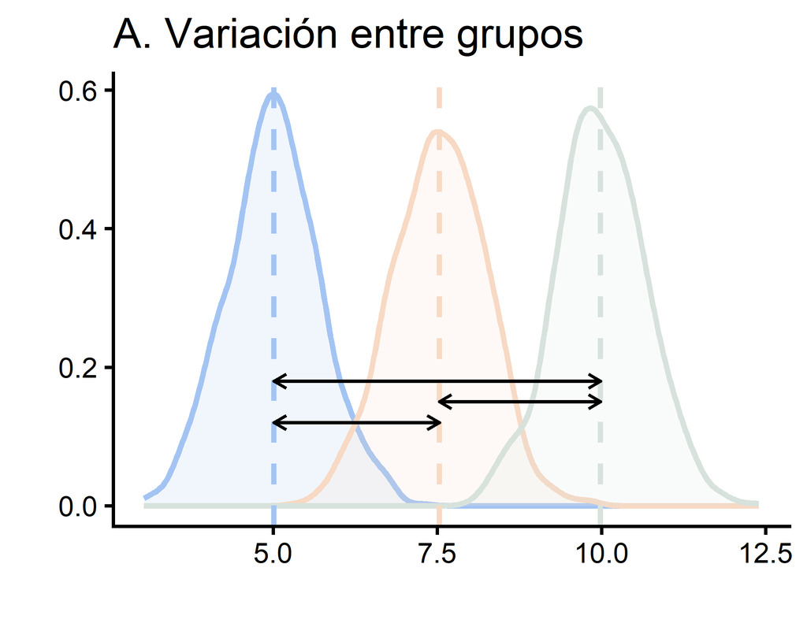

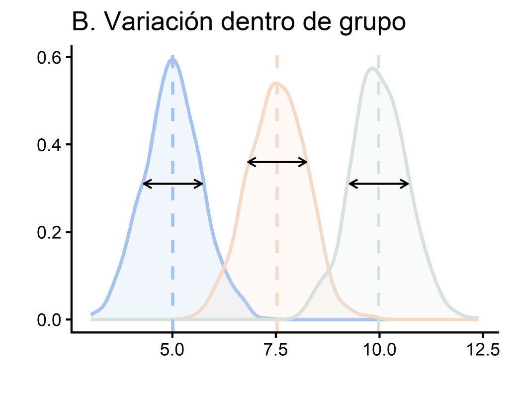

$$F = \frac{\text{Varianza ENTRE
grupos}}{\text{Varianza DENTRO de los grupos}} =
\frac{MS_{entre}}{MS_{dentro}}$$

Si la varianza **entre** grupos es suficientemente grande comparada con la varianza **dentro** de los grupos (*F* grande), concluimos que **al menos una de las medias es diferente**.

- $H_0$: $\mu_1 = \mu_2 = \dots = \mu_k$ (todas las medias son iguales)
- $H_A$: al menos una media es diferente

**Supuestos del ANOVA:**

1. **Independencia** de las observaciones.
2. **Normalidad** de los **residuos** (las desviaciones de cada observación respecto a la media de su grupo).
3. **Homogeneidad de varianzas** entre los grupos.

Seguiremos los mismos pasos que en clase ([diapositiva resumen](https://marta-coronado.github.io/biostatistics-uab/T/12/13.ANOVA_ampliado.html#80)):

1. **Visualizar** los datos.
2. Ajustar el modelo con `aov()` y **comprobar los supuestos** sobre los residuos.
3. Hacer el **test global** (ANOVA) y, si es significativo, un **test *post hoc***.
4. Cuantificar el **tamaño del efecto** ($R^2$).

## 🐝🏙️ Midiendo la biodiversidad de insectos en Los Ángeles

El declive de la biodiversidad es una de las grandes preocupaciones ambientales. Las ciudades son más cálidas, tienen menos agua disponible y su vegetación suele ser poco diversa y no nativa (por ejemplo, césped). Algunos insectos no sobreviven bien en estos ambientes, por lo que la urbanización podría reducir su diversidad y afectar a procesos como la polinización o la descomposición de la materia vegetal.

Para estudiarlo, [Adams et al. (2020)](https://esajournals.onlinelibrary.wiley.com/doi/10.1002/eap.2089) colocaron trampas para insectos en distintos puntos de Los Ángeles, con distintos niveles de urbanización, y contaron el **número de especies** capturadas en cada trampa (la **riqueza de especies**, una medida sencilla de biodiversidad).

| Columna | Descripción |
| --- | --- |
| `Sample` | identificador de la muestra (trampa) |
| `Urban.Type` | nivel de urbanización: `1` (natural), `3` (suburbano), `8` (desarrollado) y `9` (denso) |
| `Lawn` | si hay césped junto a la trampa (`Yes` / `No`) |
| `Richness` | **riqueza de especies**: número de especies de insectos capturadas |
| `Temp.Mean` | temperatura media (ºC) |
| `Photoperiod` | fotoperiodo (horas de luz) |
| `Rh.Mean` | humedad relativa media (%) |

**Nuestra pregunta:** ¿difiere la riqueza media de especies de insectos entre los niveles de urbanización?

### 1. Leer los datos

Lee el fichero [`urban_data_filter.tsv`](https://raw.githubusercontent.com/marta-coronado/biostatistics-uab/refs/heads/main/P/4/urban_data_filter.tsv) con `read.table()` (está separado por tabuladores, como en la práctica 3) y guárdalo en un objeto llamado `insectos`. Comprueba con `head()` y `str()` que se ha leído bien.

El enlace URL es: `https://raw.githubusercontent.com/marta-coronado/biostatistics-uab/refs/heads/main/P/4/urban_data_filter.tsv`

### 2. Preparar las variables

**¿Qué tipo de variable es `Richness`? ¿Y `Urban.Type`? ¿Cuál es la variable respuesta y cuál la variable explicativa (los grupos)?**

`R` ha leído `Urban.Type` como un número entero (`int`), pero en realidad es una variable **categórica**: los números 1, 3, 8 y 9 son solo códigos. Si no la convertimos en factor, `aov()` la trataría como una variable numérica y el resultado sería incorrecto.

Ejecuta el siguiente código: convierte `Urban.Type` en factor y crea una nueva columna, `Urban.Name`, con nombres más claros. La función `recode_factor()` además ordena los niveles en el orden en que los escribimos, de menos a más urbanizado ([ejemplo de `mutate()`](https://marta-coronado.github.io/biostatistics-uab/T/2/2.IntroR.html#45)).

```r
insectos <- insectos %>%
  mutate(Urban.Name = recode_factor(factor(Urban.Type),
                                    "1" = "Natural",
                                    "3" = "Suburbano",
                                    "8" = "Desarrollado",
                                    "9" = "Denso"))
```

Comprueba los niveles del factor con `levels(insectos$Urban.Name)` y cuántas trampas hay en cada nivel con `table(insectos$Urban.Name)`. **¿Tienen todos los grupos el mismo tamaño?**

### 3. Visualizar los datos

Completa la plantilla del boxplot. Con `geom_jitter()` añadimos los puntos individuales, para ver cuántas observaciones hay en cada grupo y cómo se distribuyen.

```r
ggplot(data = ___, aes(x = ___, y = ___, fill = ___)) +
  geom_boxplot(outlier.shape = NA) +
  geom_jitter(width = 0.15, alpha = 0.4) +
  theme_classic() +
  theme(legend.position = "none") +
  labs(x = "___", y = "___")
```

Calcula también el número de trampas (`n()`), la media (`mean()`) y la desviación típica (`sd()`) de `Richness` en cada nivel de urbanización, con `group_by()` y `summarize()` ([ejemplo](https://marta-coronado.github.io/biostatistics-uab/T/2/2.IntroR.html#66)):

**¿Qué nivel de urbanización parece tener más riqueza de especies? ¿Las dispersiones de los grupos parecen similares?**

### 4. Hipótesis

**Escribe la hipótesis nula y la alternativa, con palabras y con símbolos.**

### 5. Ajustar el modelo y comprobar los supuestos

Ajusta el modelo con `aov(variable_respuesta ~ grupos, data = data_frame)` y guárdalo en un objeto llamado `modelo_aov` ([ejemplo](https://marta-coronado.github.io/biostatistics-uab/T/12/13.ANOVA_ampliado.html#62)):

**a) Normalidad de los residuos.** Extrae los residuos del modelo con `resid(modelo_aov)` y aplícales el test de Shapiro-Wilk ([ejemplo](https://marta-coronado.github.io/biostatistics-uab/T/12/13.ANOVA_ampliado.html#63)):

Genera también el QQ-plot de los residuos. Ejecuta primero el siguiente bloque para cargar la función `QQ_plot()` (la misma de la práctica 3):

```r
QQ_plot <- function(vector_datos) {
  df <- data.frame(valor = vector_datos)
  ggplot(df, aes(sample = valor)) +
    stat_qq() +
    stat_qq_line(color = "firebrick4") +
    theme_classic() +
    labs(title = "QQ-plot", x = "Cuantiles teóricos", y = "Cuantiles de la muestra")
}
```

**b) Homogeneidad de varianzas.** Aplica el test de Levene: `leveneTest(variable_respuesta ~ grupos, data = data_frame)` ([ejemplo](https://marta-coronado.github.io/biostatistics-uab/T/12/13.ANOVA_ampliado.html#65)):

**¿Qué concluyes de cada test? ¿Qué te dice el QQ-plot?**

**El test de Shapiro-Wilk y el tamaño de la muestra.** Con muestras grandes (aquí tenemos 240 trampas), el test de Shapiro-Wilk detecta desviaciones de la normalidad muy pequeñas, que en la práctica no afectan al ANOVA. Por eso conviene mirar siempre también el **QQ-plot**: si los puntos siguen razonablemente la recta, el ANOVA es fiable, porque es **robusto** a desviaciones moderadas de la normalidad cuando la muestra es grande. Aun así, en el paso 9 comprobaremos el resultado con la alternativa no paramétrica.

### 6. El test de ANOVA

Aplica `summary()` al modelo para obtener la tabla del ANOVA ([ejemplo](https://marta-coronado.github.io/biostatistics-uab/T/12/13.ANOVA_ampliado.html#67)):

En la tabla, la fila del factor corresponde a la variabilidad **entre** grupos, y la fila `Residuals`, a la variabilidad **dentro** de los grupos. **Anota el valor de *F*, sus grados de libertad (`Df`) y el p-valor.**

Como vimos en clase, también podemos tomar la decisión comparando *F* con el valor crítico de la distribución *F*. Calcúlalo con `qf(0.95, df1 = gl_entre, df2 = gl_dentro)`, sustituyendo los grados de libertad por los de tu tabla ([ejemplo](https://marta-coronado.github.io/biostatistics-uab/T/12/13.ANOVA_ampliado.html#90)):

**¿Rechazas $H_0$? ¿Llegas a la misma conclusión con el p-valor y con la *F* crítica?**

### 7. Tamaño del efecto: el coeficiente de determinación $R^2$

El ANOVA nos dice **si** hay diferencias entre los grupos, pero no **cuánto** importa el factor. Para eso calculamos el **coeficiente de determinación** ($R^2$), que en el ANOVA de una vía se conoce también como **eta cuadrado** ($\eta^2$) ([diapositiva](https://marta-coronado.github.io/biostatistics-uab/T/12/13.ANOVA_ampliado.html#140)):

$$R^2 = \eta^2 =
\frac{SS_{entre}}{SS_{total}} = \frac{SS_{entre}}{SS_{entre} +
SS_{dentro}}$$

Es la **proporción de la variabilidad total** de la variable respuesta que explican los grupos. Va de 0 (el factor no explica nada) a 1 (lo explica todo).

**a) Calcúlalo a mano** con las sumas de cuadrados (`Sum Sq`) de la tabla del ANOVA:

**b) Calcúlalo con `R`.** Como el ANOVA es un modelo lineal, la función `lm()` ajusta el mismo modelo, y `summary(lm())` nos da el $R^2$ en la línea `Multiple R-squared` ([ejemplo](https://marta-coronado.github.io/biostatistics-uab/T/12/13.ANOVA_ampliado.html#144)):

```r
summary(lm(variable_respuesta ~ grupos, data = data_frame))
```

Valores orientativos de Cohen para $\eta^2$: **0.01** pequeño, **0.06** mediano, **0.14** grande (como siempre, son solo una guía: la relevancia depende del contexto).

**¿Qué porcentaje de la variabilidad de la riqueza de especies explica el nivel de urbanización? ¿Es un efecto pequeño, mediano o grande? Si el p-valor es tan pequeño, ¿por qué el $R^2$ es tan bajo?** (Pista: piensa en el tamaño de la muestra y en todo lo que puede influir en el número de especies de una trampa, además de la urbanización.)

### 8. Test *post hoc*: Tukey

El ANOVA nos dice que al menos una media es diferente, pero no **cuáles**. Para saberlo, comparamos todas las parejas de grupos con el test de Tukey (`TukeyHSD()`), que corrige por comparaciones múltiples ([ejemplo](https://marta-coronado.github.io/biostatistics-uab/T/12/13.ANOVA_ampliado.html#71)). Puedes visualizar el resultado con `plot(TukeyHSD(modelo_aov))` ([ejemplo](https://marta-coronado.github.io/biostatistics-uab/T/12/13.ANOVA_ampliado.html#74)).

**¿Qué parejas de grupos difieren significativamente (`p adj` < 0.05)? ¿Cuánto difieren sus medias?**

### 9. Comprobación no paramétrica: Kruskal-Wallis y Dunn

Como el test de Shapiro-Wilk ha dado significativo, vamos a comprobar si la alternativa no paramétrica llega a la misma conclusión ([ejemplo](https://marta-coronado.github.io/biostatistics-uab/T/12/13.ANOVA_ampliado.html#79)):

- Test global: `kruskal.test(variable_respuesta ~ grupos, data = data_frame)`.
- *Post hoc*: test de Dunn con corrección de Holm, `dunn_test(data_frame, variable_respuesta ~ grupos, p.adjust.method = "holm")`.
- Tamaño del efecto: `kruskal_effsize(data_frame, variable_respuesta ~ grupos)` (el equivalente al $\eta^2$ para Kruskal-Wallis).

**¿Llegas a las mismas conclusiones que con el ANOVA y el test de Tukey?**

### 10. Conclusión

**Completa la conclusión:**

La riqueza media de especies de insectos [sí/no] difiere entre los niveles de urbanización (ANOVA: *F* = XXXX, gl = XXXX y XXXX, p = XXXX). Según el test de Tukey, las zonas XXXX tienen más especies que las zonas XXXX y XXXX. Sin embargo, el nivel de urbanización explica solo el XXXX% de la variabilidad de la riqueza de especies ($R^2$ = XXXX), un efecto XXXX.

# Parte 2. Regresión lineal simple

## Recordatorio: correlación y regresión

- La **correlación** ($r$) mide la **fuerza** y la **dirección** de la relación lineal entre dos variables cuantitativas. Es simétrica: no distingue entre variable explicativa y respuesta.
- La **regresión lineal** ajusta la **recta** que mejor predice una variable respuesta ($Y$) a partir de una variable explicativa ($X$):

$$Y = a + b\,X$$

donde $a$ es la **ordenada en el origen** (*intercept*: el valor de $Y$ cuando $X = 0$) y $b$ es la **pendiente** (cuánto cambia $Y$, de media, cuando $X$ aumenta una unidad).

- El contraste de hipótesis de la regresión se hace sobre la pendiente: $H_0$: $\beta = 0$ (no hay relación lineal) frente a $H_A$: $\beta \neq 0$.
- El **coeficiente de determinación** ($R^2$) es la proporción de la variabilidad de $Y$ que explica la recta. En la regresión lineal simple, $R^2 = r^2$.

**Supuestos de la regresión lineal:**

1. **Linealidad**: la relación entre $X$ e $Y$ es lineal.
2. **Independencia** de las observaciones.
3. **Normalidad de los residuos**.
4. **Homocedasticidad**: la varianza de los residuos es constante a lo largo de los valores de $X$.

## 🐺 Endogamia y supervivencia de las crías en lobos

La población de lobos (*Canis lupus*) de Escandinavia se fundó a principios de los años 80 a partir de solo dos individuos (en 1991 llegó un tercero), y ha estado prácticamente aislada. Como consecuencia, los lobos de esta población están muy emparentados entre sí. [Liberg et al. (2005)](https://royalsocietypublishing.org/doi/10.1098/rsbl.2004.0266) estudiaron si la **endogamia** reduce la supervivencia de las crías. Para 24 camadas, midieron:

- `inbreedCoef`: el **coeficiente de endogamia** de la camada (de 0, sin endogamia, a 1).
- `nPups`: el **número de crías** que sobrevivieron a su primer invierno.

Datos de: *Whitlock, Michael C, and Dolph Schluter. 2020. The Analysis of Biological Data. Third Edition* (ejemplo 16.2).

**Nuestra pregunta:** ¿las camadas más endogámicas tienen menos crías que sobreviven? ¿Cuántas crías esperaríamos para un determinado nivel de endogamia?

### 1. Leer los datos

Lee el fichero [`chap16e2InbreedingWolves.csv`](https://raw.githubusercontent.com/marta-coronado/biostatistics-uab/refs/heads/main/P/4/chap16e2InbreedingWolves.csv) con `read.csv()` y guárdalo en un objeto llamado `lobos`. Comprueba con `head()` y `nrow()` que se ha leído bien.

El enlace URL es: `https://raw.githubusercontent.com/marta-coronado/biostatistics-uab/refs/heads/main/P/4/chap16e2InbreedingWolves.csv`

**¿Cuál es la variable explicativa ($X$) y cuál la variable respuesta ($Y$)?**

### 2. Visualizar los datos

En una regresión, lo primero es siempre hacer un **diagrama de dispersión**, con la variable explicativa en el eje x y la respuesta en el eje y. Completa la plantilla:

```r
ggplot(data = ___, aes(x = ___, y = ___)) +
  geom_point(size = 2) +
  theme_classic() +
  labs(x = "___", y = "___")
```

**¿Qué tipo de relación ves (positiva, negativa, ninguna)? ¿Parece lineal?**

### 3. Correlación

Calcula el coeficiente de correlación de Pearson con `cor.test(~ variable_1 + variable_2, data = data_frame)` ([ejemplo](https://marta-coronado.github.io/biostatistics-uab/T/13/14.Correlacion.html#27)):

**¿Cuánto vale $r$? ¿Es significativa la correlación?**

### 4. Ajustar la recta de regresión

La regresión lineal se ajusta con la función `lm()` (*linear model*), con la misma fórmula que usábamos en el ANOVA: `lm(variable_respuesta ~ variable_explicativa, data = data_frame)`. Ajusta el modelo, guárdalo en un objeto llamado `modelo_lm` y aplícale `summary()`:

En la salida de `summary()`, fíjate en:

- **`Coefficients`**: la columna `Estimate` da la **ordenada en el origen** (`(Intercept)`, $a$) y la **pendiente** (la fila de la variable explicativa, $b$). La columna `Pr(>|t|)` de la pendiente es el p-valor del contraste $H_0$: $\beta = 0$.
- **`Multiple R-squared`**: el **coeficiente de determinación** $R^2$.

**a) Escribe la ecuación de la recta** ($Y = a + b\,X$) con los valores que has obtenido.

**b) Interpreta la pendiente.** ¿Cuántas crías menos sobreviven, de media, por cada aumento de 0.1 en el coeficiente de endogamia?

**c) ¿Es la pendiente significativamente distinta de 0?** ¿Coincide el p-valor con el de la correlación del paso 3?

### 5. Comprobar los supuestos

**a) Linealidad**: lo hemos visto en el diagrama de dispersión del paso 2.

**b) Normalidad de los residuos**: aplica el test de Shapiro-Wilk a `resid(modelo_lm)` y genera su QQ-plot con la función `QQ_plot()`:

**c) Homocedasticidad**: ejecuta el siguiente código, que representa los **residuos** frente a los **valores ajustados** por la recta (`fitted()`). Si se cumple la homocedasticidad, los puntos deben repartirse sin ningún patrón alrededor de la línea del 0, con una dispersión parecida de izquierda a derecha (sin forma de embudo):

```r
residuos_lobos <- data.frame(ajustados = fitted(modelo_lm),
                             residuos  = resid(modelo_lm))

ggplot(residuos_lobos, aes(x = ajustados, y = residuos)) +
  geom_point(size = 2) +
  geom_hline(yintercept = 0, linetype = "dashed", color = "firebrick4") +
  theme_classic() +
  labs(x = "Valores ajustados", y = "Residuos")
```

**¿Se cumplen los supuestos?** Ten en cuenta que `nPups` es un número de crías (solo puede tomar valores enteros, entre 1 y 8) y que solo tenemos 24 camadas.

### 6. Tamaño del efecto: $R^2$

**a) ¿Qué proporción de la variabilidad del número de crías explica el coeficiente de endogamia?**

**b)** Comprueba que, en la regresión lineal simple, $R^2 = r^2$: eleva al cuadrado el coeficiente de correlación del paso 3.

**c)** La regresión también tiene su **tabla ANOVA**, que obtenemos con `anova(modelo_lm)`. Calcula el $R^2$ con las sumas de cuadrados, igual que en la parte 1: $R^2 = SS_{regresión} / (SS_{regresión} + SS_{residuos})$.

El $R^2$ es el **mismo concepto** en el ANOVA y en la regresión: la proporción de la variabilidad total que explica el modelo. La única diferencia es que en el ANOVA la variable explicativa es categórica (grupos) y en la regresión es cuantitativa.

**¿Qué modelo explica más variabilidad, el de la parte 1 (urbanización) o el de los lobos (endogamia)?**

### 7. Visualizar la recta y hacer predicciones

Añade la recta de regresión al diagrama de dispersión con `geom_smooth(method = "lm")`. La banda gris es el intervalo de confianza del 95% de la recta.

```r
ggplot(data = ___, aes(x = ___, y = ___)) +
  geom_point(size = 2) +
  geom_smooth(method = "lm", color = "firebrick4") +
  theme_classic() +
  labs(x = "___", y = "___")
```

Una de las utilidades de la regresión es **predecir**. Con la función `predict()`, calcula cuántas crías esperaríamos en una camada con un coeficiente de endogamia de 0.25:

```r
predict(modelo_lm, newdata = data.frame(inbreedCoef = 0.25))
```

**Comprueba el resultado con la ecuación de la recta del paso 4. ¿Tendría sentido usar la recta para predecir el número de crías con un coeficiente de endogamia de 0.8?** (Pista: mira el rango de valores de `inbreedCoef` en los datos.)

### 8. Conclusión

**Completa la conclusión:**

El número de crías que sobreviven a su primer invierno [aumenta/disminuye] con el coeficiente de endogamia ($b$ = XXXX, p = XXXX). Por cada aumento de 0.1 en el coeficiente de endogamia, sobreviven de media XXXX crías menos. La endogamia explica el XXXX% de la variabilidad en el número de crías ($R^2$ = XXXX).

# Para practicar: ¿qué variables ambientales explican la biodiversidad?

Vuelve a los datos de los insectos (`insectos`). Además del nivel de urbanización, se midieron tres variables ambientales cuantitativas: la temperatura media (`Temp.Mean`), la humedad relativa media (`Rh.Mean`) y el fotoperiodo (`Photoperiod`).

Haz una **regresión lineal** de la riqueza de especies (`Richness`) frente a cada una de estas tres variables: dibuja el diagrama de dispersión con la recta, ajusta el modelo con `lm()` y anota la pendiente, su p-valor y el $R^2$. **¿Qué variable explica más variabilidad de la riqueza de especies? ¿Cómo interpretas el resultado?**

# Resumen: ANOVA y regresión

|  | ANOVA de una vía | Regresión lineal simple |
| --- | --- | --- |
| Variable respuesta | cuantitativa | cuantitativa |
| Variable explicativa | **categórica** (grupos) | **cuantitativa** |
| Función en `R` | `aov(y ~ grupos)` + `summary()` | `lm(y ~ x)` + `summary()` |
| Hipótesis nula | todas las medias son iguales | la pendiente es 0 ($\beta = 0$) |
| Supuestos | independencia, normalidad de los residuos, homogeneidad de varianzas | independencia, linealidad, normalidad de los residuos, homocedasticidad |
| Tamaño del efecto | $R^2 = \eta^2 = SS_{entre} / SS_{total}$ | $R^2 = SS_{regresión} / SS_{total}$ ($= r^2$) |
| Si no se cumplen los supuestos | Kruskal-Wallis + Dunn | correlación de Spearman |